# Hoskins_Task2

## Student Name: Ash Hoskins,#S559245

## Course: CSIS 44-609 - Data Analytics Fundamentals

## Domain: Geospatial Data Module 6 Project Date: 2/20/2023

## This notebook is for Task 2 in Module 6

Task 2 Requirements:

1. Follow the instructions for Exercise 9.16 (starting pg. 350).
2. Complete the exercise in a notebook.
3. 1-Load: Get the file, store it in your repo, and load it into a DataFrame.
4. 2-View: Display the first 7 rows and the last 7 rows.
5. 3-Describe: Use the DataFrame describe() function to calculate basic descriptive statistics for all numeric columns.
6. 4-Series: Use the Series method describe() to calculate the descriptive stats for all category/text columns.
7. 5-Unique: Use the Series method unique() to get unique category values.
8. 6Histograms: Use the DataFrame's hist() function to create a histogram for each numerical column.
9. Required: Use Section headings in your Markdown to make it clear that each of these sections are shown in your notebook. They should be numbered 1-5 and include the keyword shown above.
10. Required: Include the title of the notebook, and your name and date at the top.
11. Do these consistently. A heading and section titles is required in every notebook.

```python
#import libraries
import pandas as pd
```

### 1-Load: Get the file, store it in your repo, and load it into a DataFrame.

```python
#Task 2 Requirement #3
df = pd.read_csv('diamonds.csv', index_col =0)

#Task 2 Requirement #4 - Display the first 7 rows
df.head(7)
```

|  | carat | cut | color | clarity | depth | table | price | x | y | z |
| --- | --- | --- | --- | --- | --- | --- | --- | --- | --- | --- |
| 1 | 0.23 | Ideal | E | SI2 | 61.5 | 55.0 | 326 | 3.95 | 3.98 | 2.43 |
| 2 | 0.21 | Premium | E | SI1 | 59.8 | 61.0 | 326 | 3.89 | 3.84 | 2.31 |
| 3 | 0.23 | Good | E | VS1 | 56.9 | 65.0 | 327 | 4.05 | 4.07 | 2.31 |
| 4 | 0.29 | Premium | I | VS2 | 62.4 | 58.0 | 334 | 4.20 | 4.23 | 2.63 |
| 5 | 0.31 | Good | J | SI2 | 63.3 | 58.0 | 335 | 4.34 | 4.35 | 2.75 |
| 6 | 0.24 | Very Good | J | VVS2 | 62.8 | 57.0 | 336 | 3.94 | 3.96 | 2.48 |
| 7 | 0.24 | Very Good | I | VVS1 | 62.3 | 57.0 | 336 | 3.95 | 3.98 | 2.47 |

### 2-View: Display the first 7 rows and the last 7 rows.

```python
#Task 2 Requirement #4 - Display  Last 7 rows.
df.tail(7)
```

|  | carat | cut | color | clarity | depth | table | price | x | y | z |
| --- | --- | --- | --- | --- | --- | --- | --- | --- | --- | --- |
| 53934 | 0.70 | Very Good | E | VS2 | 61.2 | 59.0 | 2757 | 5.69 | 5.72 | 3.49 |
| 53935 | 0.72 | Premium | D | SI1 | 62.7 | 59.0 | 2757 | 5.69 | 5.73 | 3.58 |
| 53936 | 0.72 | Ideal | D | SI1 | 60.8 | 57.0 | 2757 | 5.75 | 5.76 | 3.50 |
| 53937 | 0.72 | Good | D | SI1 | 63.1 | 55.0 | 2757 | 5.69 | 5.75 | 3.61 |
| 53938 | 0.70 | Very Good | D | SI1 | 62.8 | 60.0 | 2757 | 5.66 | 5.68 | 3.56 |
| 53939 | 0.86 | Premium | H | SI2 | 61.0 | 58.0 | 2757 | 6.15 | 6.12 | 3.74 |
| 53940 | 0.75 | Ideal | D | SI2 | 62.2 | 55.0 | 2757 | 5.83 | 5.87 | 3.64 |

### 3-Describe: Use the DataFrame describe() function to calculate basic descriptive statistics for all numeric columns.

```python
#Task 2 Requirement #5 -  Use the DataFrame describe() function to calculate basic descriptive statistics for all numeric columns
df.describe()
```

|  | carat | depth | table | price | x | y | z |
| --- | --- | --- | --- | --- | --- | --- | --- |
| count | 53940.000000 | 53940.000000 | 53940.000000 | 53940.000000 | 53940.000000 | 53940.000000 | 53940.000000 |
| mean | 0.797940 | 61.749405 | 57.457184 | 3932.799722 | 5.731157 | 5.734526 | 3.538734 |
| std | 0.474011 | 1.432621 | 2.234491 | 3989.439738 | 1.121761 | 1.142135 | 0.705699 |
| min | 0.200000 | 43.000000 | 43.000000 | 326.000000 | 0.000000 | 0.000000 | 0.000000 |
| 25% | 0.400000 | 61.000000 | 56.000000 | 950.000000 | 4.710000 | 4.720000 | 2.910000 |
| 50% | 0.700000 | 61.800000 | 57.000000 | 2401.000000 | 5.700000 | 5.710000 | 3.530000 |
| 75% | 1.040000 | 62.500000 | 59.000000 | 5324.250000 | 6.540000 | 6.540000 | 4.040000 |
| max | 5.010000 | 79.000000 | 95.000000 | 18823.000000 | 10.740000 | 58.900000 | 31.800000 |

### 4-Series: Use the Series method describe() to calculate the descriptive stats for all category/text columns.

```python
#Task 2 Requirement #6 - Use the Series method describe() to calculate the descriptive stats for all category/text columns.
df.describe(include =[object])
```

|  | cut | color | clarity |
| --- | --- | --- | --- |
| count | 53940 | 53940 | 53940 |
| unique | 5 | 7 | 8 |
| top | Ideal | G | SI1 |
| freq | 21551 | 11292 | 13065 |

### 4-Unique: Use the Series method unique() to get unique category values.

```python
#Task 2 Requirement #7 -    Use the Series method unique() to get unique category values.
cut = df['cut'].unique()

print(cut)
```

```
['Ideal' 'Premium' 'Good' 'Very Good' 'Fair']
```

### 5-Histograms: Use the DataFrame's hist() function to create a histogram for each numerical column.

```
array([[<AxesSubplot: title={'center': 'carat'}>,
        <AxesSubplot: title={'center': 'depth'}>,
        <AxesSubplot: title={'center': 'table'}>],
       [<AxesSubplot: title={'center': 'price'}>,
        <AxesSubplot: title={'center': 'x'}>,
        <AxesSubplot: title={'center': 'y'}>],
       [<AxesSubplot: title={'center': 'z'}>, <AxesSubplot: >,
        <AxesSubplot: >]], dtype=object)
```

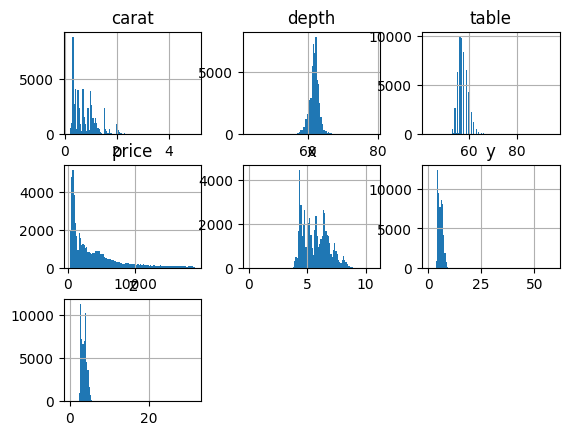

```python
#Task 2 Requirement #8 - Use the DataFrame's hist() function to create a histogram for each numerical column.
df.hist(bins = 100)
```